# Predicting the Exercise

### Predicting how well exercises were done

#### Summary

The exercises taken by 6 subjects, which were either measurements from accelerometers on the belt, forearm, arm, and dumbell of 6 participants. The data was taken from http://groupware.les.inf.puc-rio.br/har, which was taken from devices such as devices such as *Jawbone Up*, *Nike FuelBand*, and *Fitbit*. It was portioned into a training and a testing data set and was used to predict how well each exercise was done (variable *classe*), using random forest machine learning.

#### Parsing the data set

When conducitng exploratory analysis, it was shown that many of the variables were not well populated and so only the sixty in the subset *training_sub* and *testing_sub* were used.

```r
library(caret)

# loading the 2 data sets
training <- read.csv("pml-training.csv", stringsAsFactors = FALSE)
testing <- read.csv("pml-testing.csv", stringsAsFactors = FALSE)
table(training$classe)
```

```
##
##    A    B    C    D    E
## 5580 3797 3422 3216 3607
```

```r
names(training) <- gsub("picth", "pitch", names(training)) # rename a typo
list <- c(12:17, 20, 23, 26, 69:74, 87:92, 95, 98, 101, 125:130, 133, 136, 139)
for (i in list) training[,i] <- as.numeric(training[,i]) # ensure all variables are numeric
for (i in list) testing[,i] <- as.numeric(testing[,i]) # ensure all variables are numeric

# keep only well populated rows
x <- list()
for (i in 1:ncol(training)) x[i] <- sum(is.na(training[,i]))
training_sub <- training[,c(1:11, 37:49, 60:68, 84:86, 102, 113:124, 140, 151:160)]
testing_sub <- testing[,c(1:11, 37:49, 60:68, 84:86, 102, 113:124, 140, 151:160)]

# get my own training and testing sets
inTrain = createDataPartition(training_sub$classe, p = 0.6)[[1]]
my_training <- training_sub[inTrain,]
my_testing <- training_sub[-inTrain,]

# test for linear combinations
comboInfo <- findLinearCombos(my_training[,8:59])
comboInfo # this shows there are no linear combinations of variables.
```

```
## $linearCombos
## list()
##
## $remove
## NULL
```

#### Results

Four different machine learning techniques were compared to determine which was the most accurate, using the *my_training* and *my_testing* datasets. The most accurate was then used to predict the *classe* in the given testing set. The first is linear discriminant analysis (LDA) which provides a linear combination of variable effects, much like generalised linear regression, to explain the prediction varialbe. Random forest (RF) is an ensemble learning technique for classification (in this case for predicting *classe*), by constructing multiple decision trees to predict the classifications. The third technique is support vector machine (SVM) learning, which is a supervised learning technique meaning that it assigns new examples based on previously learnt classifications. NOtably it isn’t probabilistic. The final technique is generalised boosting methods (GBM), which is a probabilistic method that produces a prediction model in a stepwise method.

```r
library(caret)
set.seed(325)
# lda
ldaFit1 <- train(classe ~ ., data = my_training[,8:60], method = "lda")

# random forest
rfFit1 <- train(classe ~ ., data = my_training[,8:60], method = "rf")

# SVM
svmFit1 <- train(classe ~ ., data = my_training[,8:60], method = "svmRadial")

# GBM
gbmFit1 <- train(classe ~ ., data = my_training[,8:60], method = "gbm")
```

After computation, the 4 methods were compared below to determine their accuracy. The confusion matrices show that the most accurate technique was random forest.

```r
library(caret)
# lda
predlda <- predict(ldaFit1, newdata = my_testing[,c(8:59)])
confusionMatrix(predlda, my_testing$classe)
```

```
## Confusion Matrix and Statistics
##
##           Reference
## Prediction    A    B    C    D    E
##          A 1845  230  148   73   64
##          B   56  988  144   65  257
##          C  168  171  886  152  135
##          D  154   62  163  938  124
##          E    9   67   27   58  862
##
## Overall Statistics
##
##                Accuracy : 0.7034
##                  95% CI : (0.6932, 0.7135)
##     No Information Rate : 0.2845
##     P-Value [Acc > NIR] : < 2.2e-16
##
##                   Kappa : 0.6244
##  Mcnemar's Test P-Value : < 2.2e-16
##
## Statistics by Class:
##
##                      Class: A Class: B Class: C Class: D Class: E
## Sensitivity            0.8266   0.6509   0.6477   0.7294   0.5978
## Specificity            0.9083   0.9175   0.9034   0.9233   0.9749
## Pos Pred Value         0.7818   0.6543   0.5860   0.6509   0.8426
## Neg Pred Value         0.9295   0.9164   0.9239   0.9457   0.9150
## Prevalence             0.2845   0.1935   0.1744   0.1639   0.1838
## Detection Rate         0.2352   0.1259   0.1129   0.1196   0.1099
## Detection Prevalence   0.3008   0.1925   0.1927   0.1837   0.1304
## Balanced Accuracy      0.8674   0.7842   0.7755   0.8264   0.7863
```

```r
# random forest
predrf <- predict(rfFit1, newdata = my_testing[,c(8:59)])
confusionMatrix(predrf, my_testing$classe)
```

```
## Confusion Matrix and Statistics
##
##           Reference
## Prediction    A    B    C    D    E
##          A 2231   18    0    0    0
##          B    0 1492    9    0    0
##          C    0    8 1354   19    8
##          D    0    0    5 1265    1
##          E    1    0    0    2 1433
##
## Overall Statistics
##
##                Accuracy : 0.991
##                  95% CI : (0.9886, 0.9929)
##     No Information Rate : 0.2845
##     P-Value [Acc > NIR] : < 2.2e-16
##
##                   Kappa : 0.9886
##  Mcnemar's Test P-Value : NA
##
## Statistics by Class:
##
##                      Class: A Class: B Class: C Class: D Class: E
## Sensitivity            0.9996   0.9829   0.9898   0.9837   0.9938
## Specificity            0.9968   0.9986   0.9946   0.9991   0.9995
## Pos Pred Value         0.9920   0.9940   0.9748   0.9953   0.9979
## Neg Pred Value         0.9998   0.9959   0.9978   0.9968   0.9986
## Prevalence             0.2845   0.1935   0.1744   0.1639   0.1838
## Detection Rate         0.2843   0.1902   0.1726   0.1612   0.1826
## Detection Prevalence   0.2866   0.1913   0.1770   0.1620   0.1830
## Balanced Accuracy      0.9982   0.9907   0.9922   0.9914   0.9966
```

```r
# SVM
predsvm <- predict(svmFit1, newdata = my_testing[,c(8:59)])
confusionMatrix(predsvm, my_testing$classe)
```

```
## Confusion Matrix and Statistics
##
##           Reference
## Prediction    A    B    C    D    E
##          A 2215  151   20    7    3
##          B    8 1317   62    2   19
##          C    6   49 1239  163   66
##          D    0    0   47 1110   41
##          E    3    1    0    4 1313
##
## Overall Statistics
##
##                Accuracy : 0.9169
##                  95% CI : (0.9106, 0.9229)
##     No Information Rate : 0.2845
##     P-Value [Acc > NIR] : < 2.2e-16
##
##                   Kappa : 0.8946
##  Mcnemar's Test P-Value : < 2.2e-16
##
## Statistics by Class:
##
##                      Class: A Class: B Class: C Class: D Class: E
## Sensitivity            0.9924   0.8676   0.9057   0.8631   0.9105
## Specificity            0.9678   0.9856   0.9562   0.9866   0.9988
## Pos Pred Value         0.9245   0.9354   0.8135   0.9265   0.9939
## Neg Pred Value         0.9969   0.9688   0.9796   0.9735   0.9802
## Prevalence             0.2845   0.1935   0.1744   0.1639   0.1838
## Detection Rate         0.2823   0.1679   0.1579   0.1415   0.1673
## Detection Prevalence   0.3054   0.1795   0.1941   0.1527   0.1684
## Balanced Accuracy      0.9801   0.9266   0.9309   0.9249   0.9546
```

```r
# GBM
predgbm <- predict(gbmFit1, newdata = my_testing[,c(8:59)])
confusionMatrix(predgbm, my_testing$classe)
```

```
## Confusion Matrix and Statistics
##
##           Reference
## Prediction    A    B    C    D    E
##          A 2203   53    0    0    2
##          B   22 1427   37    1   15
##          C    5   27 1312   43   20
##          D    0    5   19 1235   16
##          E    2    6    0    7 1389
##
## Overall Statistics
##
##                Accuracy : 0.9643
##                  95% CI : (0.96, 0.9683)
##     No Information Rate : 0.2845
##     P-Value [Acc > NIR] : < 2.2e-16
##
##                   Kappa : 0.9548
##  Mcnemar's Test P-Value : NA
##
## Statistics by Class:
##
##                      Class: A Class: B Class: C Class: D Class: E
## Sensitivity            0.9870   0.9401   0.9591   0.9603   0.9632
## Specificity            0.9902   0.9881   0.9853   0.9939   0.9977
## Pos Pred Value         0.9756   0.9501   0.9325   0.9686   0.9893
## Neg Pred Value         0.9948   0.9857   0.9913   0.9922   0.9918
## Prevalence             0.2845   0.1935   0.1744   0.1639   0.1838
## Detection Rate         0.2808   0.1819   0.1672   0.1574   0.1770
## Detection Prevalence   0.2878   0.1914   0.1793   0.1625   0.1789
## Balanced Accuracy      0.9886   0.9641   0.9722   0.9771   0.9805
```

```r
# comparing performance
resamps <- resamples(list(LDA = ldaFit1,
                          RF = rfFit1,
                          GBM = gbmFit1,
                          SVM = svmFit1))
resamps
```

```
##
## Call:
## resamples.default(x = list(LDA = ldaFit1, RF = rfFit1, GBM = gbmFit1,
##  SVM = svmFit1))
##
## Models: LDA, RF, GBM, SVM
## Number of resamples: 25
## Performance metrics: Accuracy, Kappa
## Time estimates for: everything, final model fit
```

```r
summary(resamps)
```

```
##
## Call:
## summary.resamples(object = resamps)
##
## Models: LDA, RF, GBM, SVM
## Number of resamples: 25
##
## Accuracy
##       Min. 1st Qu. Median   Mean 3rd Qu.   Max. NA's
## LDA 0.6903  0.6988 0.7034 0.7029  0.7063 0.7127    0
## RF  0.9833  0.9840 0.9859 0.9863  0.9878 0.9921    0
## GBM 0.9508  0.9529 0.9559 0.9558  0.9575 0.9636    0
## SVM 0.9125  0.9164 0.9200 0.9198  0.9224 0.9282    0
##
## Kappa
##       Min. 1st Qu. Median   Mean 3rd Qu.   Max. NA's
## LDA 0.6084  0.6192 0.6245 0.6241  0.6284 0.6364    0
## RF  0.9788  0.9798 0.9821 0.9827  0.9845 0.9900    0
## GBM 0.9375  0.9404 0.9442 0.9441  0.9461 0.9539    0
## SVM 0.8890  0.8941 0.8984 0.8984  0.9017 0.9093    0
```

```r
difValues <- diff(resamps)
difValues
```

```
##
## Call:
## diff.resamples(x = resamps)
##
## Models: LDA, RF, GBM, SVM
## Metrics: Accuracy, Kappa
## Number of differences: 6
## p-value adjustment: bonferroni
```

```r
summary(difValues)
```

```
##
## Call:
## summary.diff.resamples(object = difValues)
##
## p-value adjustment: bonferroni
## Upper diagonal: estimates of the difference
## Lower diagonal: p-value for H0: difference = 0
##
## Accuracy
##     LDA       RF        GBM       SVM
## LDA           -0.28342  -0.25291  -0.21691
## RF  < 2.2e-16            0.03050   0.06651
## GBM < 2.2e-16 < 2.2e-16            0.03601
## SVM < 2.2e-16 < 2.2e-16 < 2.2e-16
##
## Kappa
##     LDA       RF        GBM       SVM
## LDA           -0.35862  -0.32000  -0.27433
## RF  < 2.2e-16            0.03861   0.08429
## GBM < 2.2e-16 < 2.2e-16            0.04568
## SVM < 2.2e-16 < 2.2e-16 < 2.2e-16
```

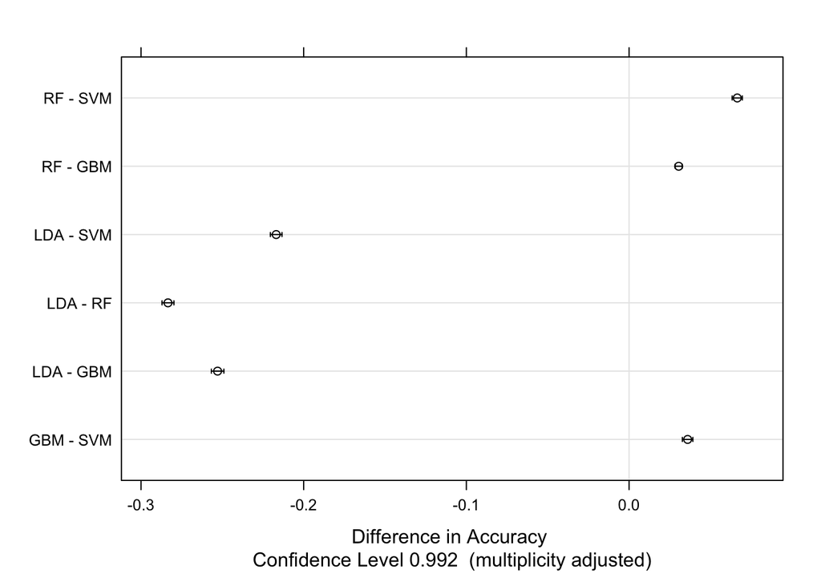

```r
trellis.par.set(caretTheme())
dotplot(difValues)
```

```r
ctrl <- trainControl(method="cv",
                     summaryFunction=defaultSummary,
                     classProbs=T,
                     savePredictions = T)
rfFit <- train(classe ~ ., data=training_sub,
               method="rf", preProc=c("center", "scale"),
               trControl=ctrl)
library(pROC)
```

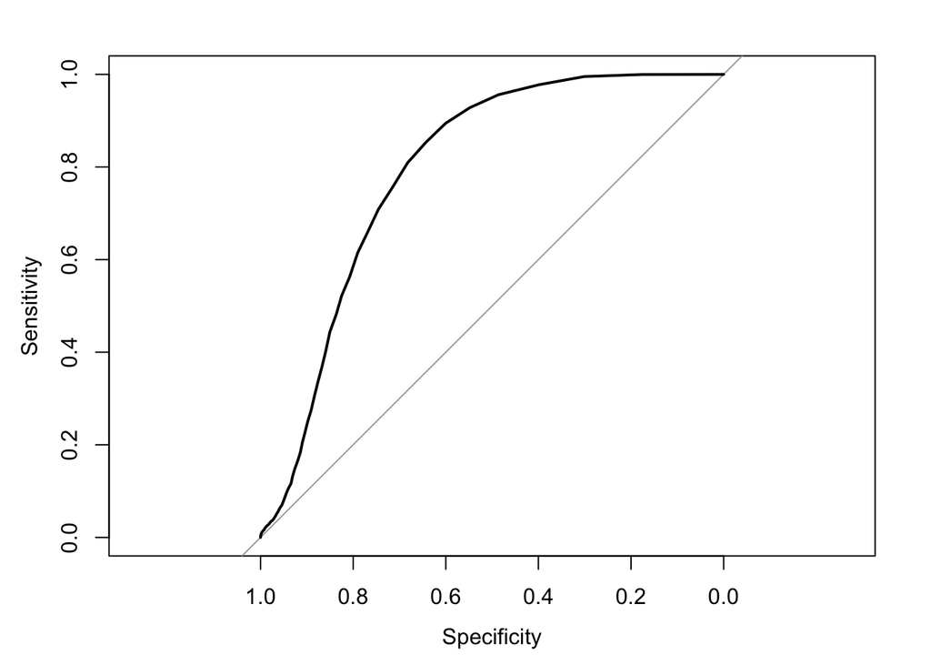

```
##
## Call:
## plot.roc.default(x = rfFit$pred$obs[selectedIndices], predictor = rfFit$pred$D[selectedIndices])
##
## Data: rfFit$pred$D[selectedIndices] in 5580 controls (rfFit$pred$obs[selectedIndices] A) < 3797 cases (rfFit$pred$obs[selectedIndices] B).
## Area under the curve: 0.7934
```

```r
# Select a parameter setting
selectedIndices <- rfFit$pred$mtry == 2
# Plot:
plot.roc(rfFit$pred$obs[selectedIndices],
         rfFit$pred$D[selectedIndices])
```

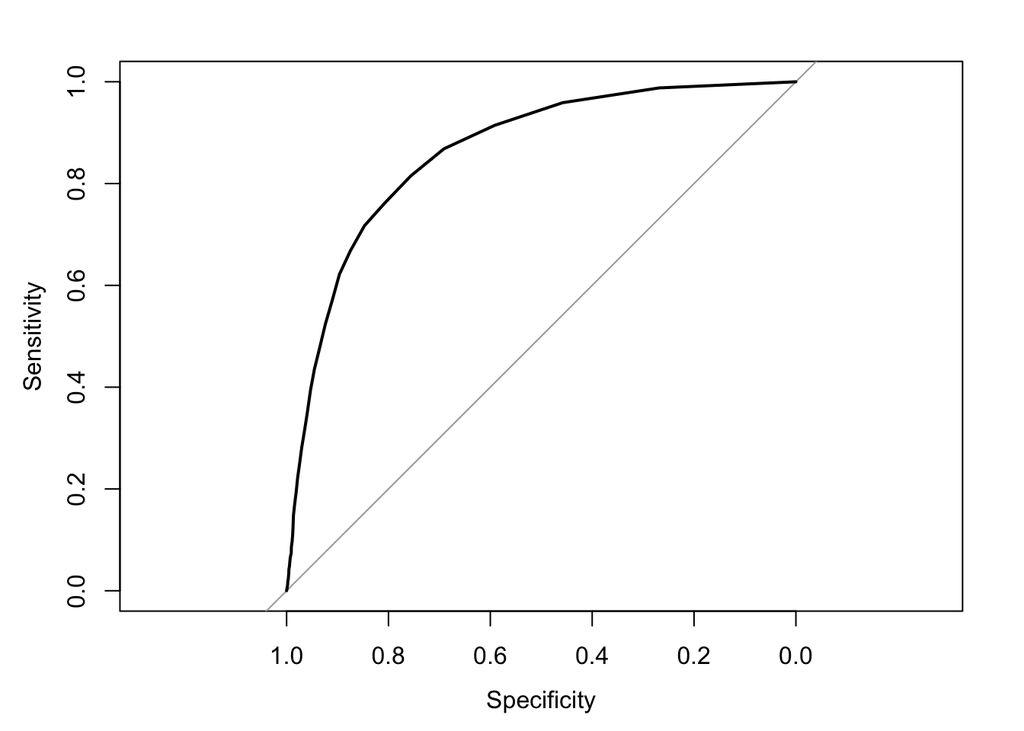

```
##
## Call:
## plot.roc.default(x = rfFit$pred$obs[selectedIndices], predictor = rfFit$pred$E[selectedIndices])
##
## Data: rfFit$pred$E[selectedIndices] in 5580 controls (rfFit$pred$obs[selectedIndices] A) < 3797 cases (rfFit$pred$obs[selectedIndices] B).
## Area under the curve: 0.8621
```

```r
plot.roc(rfFit$pred$obs[selectedIndices],
         rfFit$pred$E[selectedIndices])
```

#### Conclusions

The most accurate technique was random forest, which gave the following results in the provided testing set. It had an accuracy of 99%, whereas the other techniques were: 70% for LDA, 96% for GBM and 92% for SVM.

```r
# testing using random forest model
pred <- predict(rfFit1, newdata = testing_sub[,c(8:59)])
preda <- as.data.frame(rbind(testing_sub$problem_id, as.character(pred)))
preda
```

```
##   V1 V2 V3 V4 V5 V6 V7 V8 V9 V10 V11 V12 V13 V14 V15 V16 V17 V18 V19 V20
## 1  1  2  3  4  5  6  7  8  9  10  11  12  13  14  15  16  17  18  19  20
## 2  B  A  B  A  A  E  D  B  A   A   B   C   B   A   E   E   A   B   B   B
```